# Analyzing Austin Water Quality

Katie Yang

# Overview

### Analyzing the relationship between pathogenic bacteria and various environmental factors present in freshwater samples taken in Austin.

### Goals

#### The goals for this project is to observe how different factors and how different locations can affect E.coli presence. Additionally, we also want to be able to analyze a data set and create/conclude data visualizations and answer our hypothesis.

### Link

#### [Link to Dataset](https://drive.google.com/file/d/1hD1q0fD3gEoVmovGy9y1p7OmGgA_eDfT/view?usp=sharing)

### Information on the Data

#### This is a randomly selected subset of the larger dataset of Water Quality in different waters in Austin and the various tests conducted in these waters. Done through Google Sheets and selected a random sample of 150k (instead of 1.4 million) from the last 20 years.

```r
# Load all of the necessary libraries
library(tidyverse)
library(MASS)
library(ggplot2)
library(ggmap)
library(dplyr)
```

## Data Cleaning

```r
# Import the data Water_Quality
Water_Quality <- read.csv("~/Water_Quality_Sampling_Data_Subset_20240719.csv", header=FALSE)

# Change unnamed columns into its respective variable names from first row
col_names <- Water_Quality[1,]
colnames(Water_Quality) <- col_names

# Remove first row (column names)
Water_Quality <- Water_Quality[-1,]

# Separate month, day, year, time
Water_Quality <- Water_Quality %>% separate(SAMPLE_DATE, into = c("Date", "Time"), sep = " ")
Water_Quality <- Water_Quality %>% separate(Date, into = c("Month", "Day", "Year"), sep = "/")

# Rename some of the columns
colnames(Water_Quality)[colnames(Water_Quality) == "LAT_DD_WGS84"] <- "Latitude"
colnames(Water_Quality)[colnames(Water_Quality) == "LON_DD_WGS84"] <- "Longitude"

head(Water_Quality)
```

|  | DATA_REF_NO | SAMPLE_REF_NO | PROJECT | WATERSHED | SITE_TYPE | SAMPLE_SITE_NO | SITE_NAME | Latitude | Longitude | Month | Day | Year | Time | TIME_NULL | collecting_group | SAMPLE_ID | MEDIUM | DEPTH_IN_METERS | PARAM_TYPE | PARAMETER | QC_TYPE | QUALIFIER | RESULT | UNIT | QC_FLAG | METHOD | FILTER |
| --- | --- | --- | --- | --- | --- | --- | --- | --- | --- | --- | --- | --- | --- | --- | --- | --- | --- | --- | --- | --- | --- | --- | --- | --- | --- | --- | --- |
| 2 | 2811180 | 576071 | Stormwater Monitoring | Bear Creek | Rural runoff | 4101 | Flint Ridge D3 Runoff (FR3) | 30.15766393 | -97.87768193 | 9 | 7 | 2010 | 22:52 | N | WQM | FR3-07SEP2010-04 | Storm Water |  | Metals | LEAD |  | < | 1 | UG/L | U | EPA 200.8 | Total |
| 3 | 1356767 | 293177 | Atrazine Springs | Barton Creek | Spring | 422 | Old Mill (Sunken Gardens) Spring | 30.26358486 | -97.76807574 | 5 | 10 | 2005 | 0:00 | Y | WRE |  | Ground Water |  | Triazines | ATRAZINE (AATREX) |  | < | 0.52 | UG/L | U | EPA 507 | Total |
| 4 | 635846 | 286375 | Bull Creek Study | Bull Creek | Stream | 349 | Bull Creek Upstream of Tributary 7 (Franklin) | 30.41900917 | -97.81269688 | 8 | 17 | 2005 | 12:00 | N | WRE | #3 | Habitat |  | Habitat Evaluation | UNDERCUT BANKS |  |  | 2 | 0-4: (Absent; Sparse; Moderate; Heavy; Very heavy) | U | TCEQ HABITAT EVALUATION | Total |
| 5 | 1597076 | 214683 | Asphalt Pavement Study | Waller Creek | Parking Lot | 2376 | Parking Lot @ 407 E 9th | 30.26952061 | -97.73737617 | 1 | 13 | 2003 | 9:50 | N | WRE | 9999 B | Soil |  | PAHs | PAH (POLYCYCLIC AROMATIC HYDROCARBONS) |  |  | 3298.043 | MG/KG | U | Sediment Quality Guideline PAHs (13 parameters) | Total |
| 6 | 1771088 | 358431 | Barton Springs Salamander | Barton Creek | Spring | 422 | Old Mill (Sunken Gardens) Spring | 30.26358486 | -97.76807574 | 1 | 18 | 2011 | 11:40 | N | WRE | CC | Benthic Cover | 1.054 | Benthic Macroinvertebrates | DIPTERA (MIDGE/FLY) |  |  | 1 | 1=Present; 0=Absent | U | VISUAL ASSESSMENT | Larvae |
| 7 | 1763907 | 362266 | Environmental Integrity Index (1996-2022) | East Bouldin Creek | Stream | 119 | East Bouldin Creek @ Elizabeth St | 30.24959521 | -97.75430267 | 6 | 7 | 2011 | 11:30 | N | WRE |  | Surface Water |  | Sample Collection Methods | FIELD INSTRUMENT WRM ID |  |  | 27 | None | U | NONE | Total |

## Addressing NA’s

```r
# Find percentage of each columns' not NA
Water_Quality %>% summarize_all(function(x)mean (!is.na(x)))
```

| DATA_REF_NO | SAMPLE_REF_NO | PROJECT | WATERSHED | SITE_TYPE | SAMPLE_SITE_NO | SITE_NAME | Latitude | Longitude | Month | Day | Year | Time | TIME_NULL | collecting_group | SAMPLE_ID | MEDIUM | DEPTH_IN_METERS | PARAM_TYPE | PARAMETER | QC_TYPE | QUALIFIER | RESULT | UNIT | QC_FLAG | METHOD | FILTER |
| --- | --- | --- | --- | --- | --- | --- | --- | --- | --- | --- | --- | --- | --- | --- | --- | --- | --- | --- | --- | --- | --- | --- | --- | --- | --- | --- |
| 1 | 1 | 1 | 1 | 1 | 1 | 1 | 1 | 1 | 1 | 1 | 1 | 1 | 1 | 1 | 0.99966 | 1 | 1 | 1 | 1 | 1 | 1 | 1 | 1 | 1 | 1 | 1 |

##### Only NAs are in SAMPLE_ID which holds no significance to later analysis

## Visualize the E. coli concentration over the years

[figure not shown]

```r
# Data with just E. coli
ecoli_data <- Water_Quality[Water_Quality$PARAMETER == "E COLI BACTERIA",]

# Visualize E. coli concentrations over the years using the Colonies/100mL unit method
ecoli_data_colonies <- ecoli_data[ecoli_data$UNIT == "Colonies/100mL",]

ggplot(ecoli_data_colonies, aes(x = Year, y = RESULT)) + geom_col(alpha = 0.5, fill = "#AFE1AF") + labs(title = "E. coli Amounts Over the Years (Colonies/100mL)", x = "Year", y = "E. coli Concentration") + theme_minimal() + theme(axis.text.x = element_text(angle = 45, hjust = 1))
```

[figure not shown]

```r
# Visualize E. coli concentrations over the years the MPN/100mL unitmethod
ecoli_data_mpn <- ecoli_data[ecoli_data$UNIT == "MPN/100ML",]

ggplot(ecoli_data_mpn, aes(x = Year, y = RESULT)) + geom_col(alpha = 0.5, fill = "#4F7942") + labs(title = "E. coli Amounts Over the Years (MPN/100mL)", x = "Year", y = "E. coli Concentration (MPN/100mL)") + theme_minimal() + theme(axis.text.x = element_text(angle = 45, hjust = 1))
```

### Identifying Outliers

```r
# Create a data vector without NAs in the RESULTS column for the colonies/100mL method
ecoli_no_na_colonies <- subset(Water_Quality, UNIT == "Colonies/100mL" & !is.na(RESULT) & PARAMETER == "E COLI BACTERIA")

q1 <- quantile(as.numeric(ecoli_no_na_colonies$RESULT), 0.25, na.rm = TRUE)
q3 <- quantile(as.numeric(ecoli_no_na_colonies$RESULT), 0.75, na.rm = TRUE)
IQR <- q3 - q1
lower <- q1 - (1.5 * IQR)
upper <- q3 + (1.5 * IQR)

# Create data vector of the outliers
ecoli_outlier_colonies <- ecoli_no_na_colonies[ecoli_no_na_colonies$RESULT <= lower | ecoli_no_na_colonies$RESULT >= upper,]

head(ecoli_outlier_colonies)
```

|  | DATA_REF_NO | SAMPLE_REF_NO | PROJECT | WATERSHED | SITE_TYPE | SAMPLE_SITE_NO | SITE_NAME | Latitude | Longitude | Month | Day | Year | Time | TIME_NULL | collecting_group | SAMPLE_ID | MEDIUM | DEPTH_IN_METERS | PARAM_TYPE | PARAMETER | QC_TYPE | QUALIFIER | RESULT | UNIT | QC_FLAG | METHOD | FILTER |
| --- | --- | --- | --- | --- | --- | --- | --- | --- | --- | --- | --- | --- | --- | --- | --- | --- | --- | --- | --- | --- | --- | --- | --- | --- | --- | --- | --- |
| 199 | 2574013 | 517416 | Flint Ridge Hydrogeological Study | Bear Creek | Cave Stream | 10762 | Flint Ridge Culvert Crawl Lower Pool |  |  | 11 | 29 | 2014 | 12:00 | N | WRE | 10762 CULVERT CRAWL LOWER POOL | Ground Water |  | Bacteria/Pathogens | E COLI BACTERIA |  | J | 189 | Colonies/100mL | U | COLILERT (IDEXX METHOD) | Total |
| 789 | 1986225 | 391317 | Groundwater | Barton Creek | Spring | 35 | Barton Spring | 30.26353512 | -97.77097968 | 6 | 13 | 2012 | 0:00 | Y | ATCHD | 35 Barton Springs | Ground Water |  | Bacteria/Pathogens | E COLI BACTERIA |  |  | 6.3 | Colonies/100mL | U | UNKNOWN | Total |
| 1086 | 1535985 | 317556 | McKinney Falls State Park Bacterial Data | Onion Creek | Stream | 253 | Onion Creek @ Mckinney Falls Upper Pool | 30.18452473 | -97.72549275 | 3 | 17 | 2008 | 0:00 | Y | ATCHD |  | Surface Water |  | Bacteria/Pathogens | E COLI BACTERIA |  |  | 7 | Colonies/100mL | U | SM 9222 G | Total |
| 2029 | 2602031 | 520727 | Davis Lane Hydrogeological Study | Williamson Creek | Cave Drip | 467 | Maple Run Cave Copal Entrance |  |  | 9 | 21 | 2013 | 10:35 | N | WRE | MR Copal Entrance | Ground Water |  | Bacteria/Pathogens | E COLI BACTERIA |  |  | 727 | Colonies/100mL | U | COLILERT (IDEXX METHOD) | Total |
| 2108 | 1128053 | 234205 | Groundwater | Barton Creek | Spring | 35 | Barton Spring | 30.26353512 | -97.77097968 | 12 | 17 | 2003 | 0:00 | Y | ATCHD | BARTON SPRINGS-17DEC3-G | Ground Water |  | Bacteria/Pathogens | E COLI BACTERIA |  |  | 4 | Colonies/100mL | U | SM 9222 G | Total |
| 2188 | 608568 | 189783 | Lady Bird Lake Study | Lady Bird Lake | Lake | 5 | Lady Bird Lake @ Red Bud Isle (EC) | 30.28711129 | -97.78573004 | 10 | 25 | 2001 | 13:30 | N | WRE | TOWN 6 SURF-25OCT1-1 | Surface Water | 0.2 | Bacteria/Pathogens | E COLI BACTERIA | Field Split |  | 2 | Colonies/100mL | U | SM 9222 G | Total |

```r
# Create data vector without NAs in the RESULTS column for MPN/100ML method
ecoli_no_na_mpn <- subset(Water_Quality, UNIT == "MPN/100ML" & !is.na(RESULT) & PARAMETER == "E COLI BACTERIA")

q1_v2 <- quantile(as.numeric(ecoli_no_na_mpn$RESULT), 0.25, na.rm = TRUE)
q3_v2 <- quantile(as.numeric(ecoli_no_na_mpn$RESULT), 0.75, na.rm = TRUE)
IQR_v2 <- q3_v2 - q1_v2
lower_v2 <- q1_v2 - (1.5 * IQR_v2)
upper_v2 <- q3_v2 + (1.5 * IQR_v2)

# Create data vector of the outliers
ecoli_outlier_mpn <- ecoli_no_na_mpn[ecoli_no_na_mpn$RESULT <= lower | ecoli_no_na_mpn$RESULT >= upper,]

head(ecoli_outlier_mpn)
```

|  | DATA_REF_NO | SAMPLE_REF_NO | PROJECT | WATERSHED | SITE_TYPE | SAMPLE_SITE_NO | SITE_NAME | Latitude | Longitude | Month | Day | Year | Time | TIME_NULL | collecting_group | SAMPLE_ID | MEDIUM | DEPTH_IN_METERS | PARAM_TYPE | PARAMETER | QC_TYPE | QUALIFIER | RESULT | UNIT | QC_FLAG | METHOD | FILTER |
| --- | --- | --- | --- | --- | --- | --- | --- | --- | --- | --- | --- | --- | --- | --- | --- | --- | --- | --- | --- | --- | --- | --- | --- | --- | --- | --- | --- |
| 292 | 1838571 | 371974 | Environmental Integrity Index (1996-2022) | Running Deer Creek | Stream | 316 | Deer @ Running Deer Trail (AST) | 30.37711594 | -97.91679372 | 12 | 8 | 2011 | 11:00 | N | WRE |  | Surface Water |  | Bacteria/Pathogens | E COLI BACTERIA |  |  | 36.8 | MPN/100ML | U | COLILERT (IDEXX METHOD) | Total |
| 420 | 1742779 | 350910 | Bull Creek Contact Rec Assessment | Bull Creek | Stream | 350 | Bull Creek @ Loop 360 First Crossing | 30.3716707 | -97.78492996 | 7 | 12 | 2010 | 0:00 | Y | ATCHD |  | Surface Water |  | Bacteria/Pathogens | E COLI BACTERIA |  |  | 387.3 | MPN/100ML | U | SM 9223 B | Total |
| 427 | 1497992 | 314105 | Environmental Integrity Index (1996-2022) | Gilleland Creek | Stream | 886 | Gilleland Creek @ FM 969 | 30.25406401 | -97.54019484 | 2 | 7 | 2008 | 12:15 | N | WRE |  | Surface Water |  | Bacteria/Pathogens | E COLI BACTERIA |  |  | 36.8 | MPN/100ML | U | COLILERT (IDEXX METHOD) | Total |
| 565 | 1822529 | 362323 | Bull Creek Contact Rec Assessment | Bull Creek | Stream | 3794 | Bull Creek @ Bull Creek Dist Park (Lakewood Dr) | 30.3663747 | -97.78706492 | 4 | 4 | 2011 | 0:00 | Y | ATCHD |  | Surface Water |  | Bacteria/Pathogens | E COLI BACTERIA |  |  | 39.3 | MPN/100ML | U | SM 9223 B | Total |
| 795 | 1739781 | 349466 | Wilbarger RWA | Wilbarger Creek | Stream | 4460 | Wilbarger @ Lower Elgin Rd | 30.22244093 | -97.40929762 | 5 | 10 | 2010 | 12:40 | N | WRE | 4460-WIL @ Lower Elgin | Surface Water |  | Bacteria/Pathogens | E COLI BACTERIA |  |  | 91 | MPN/100ML | U | SM 9223 B | Total |
| 799 | 2862796 | 576679 | Stormwater Monitoring | Lady Bird Lake | BMP - Wet Pond | 2471 | Sand Beach Influent (SBI) | 30.26708 | -97.755484 | 5 | 10 | 2012 | 21:03 | N | WQM | SBI-10MAY2012-01 | Storm Water |  | Bacteria/Pathogens | E COLI BACTERIA |  | H | 548000 | MPN/100ML | U | SM 9223 B | Total |

# Data Visualizations

### Initial Findings

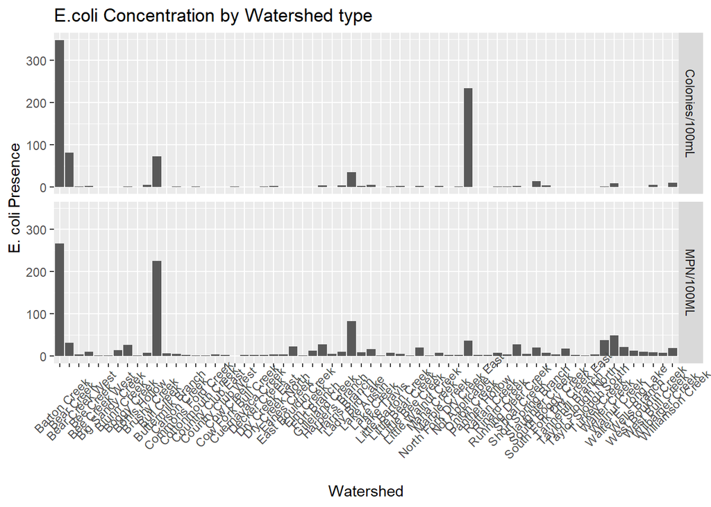

```r
# Visualization 1 - Bar Graph displaying E. coli Presence by Watershed type and separated by unit
ggplot(ecoli_data, aes(x = WATERSHED)) + geom_bar(alpha = 1) + theme(axis.text.x = element_text(angle = 45, vjust = 0.7)) + labs(title = 'E.coli Concentration by Watershed type', x = 'Watershed', y = 'E. coli Presence') + facet_grid(UNIT ~ .)
```

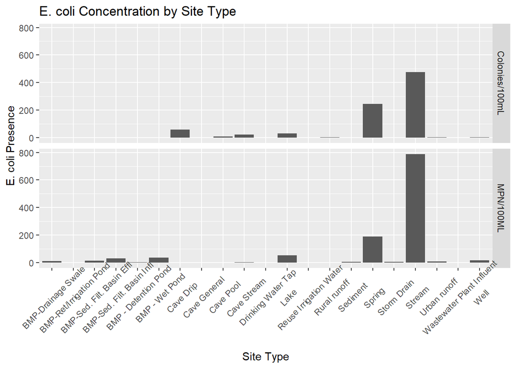

```r
# Visualization 2 - Bar Graph displaying E. coli Presence by Site type and separated by unit
ggplot(ecoli_data, aes(x = SITE_TYPE)) + geom_bar(alpha = 1) + theme(axis.text.x = element_text(angle = 45, vjust = 0.7)) + labs(title = 'E. coli Concentration by Site Type', x = "Site Type", y = "E. coli Presence") + facet_grid(UNIT ~ .)
```

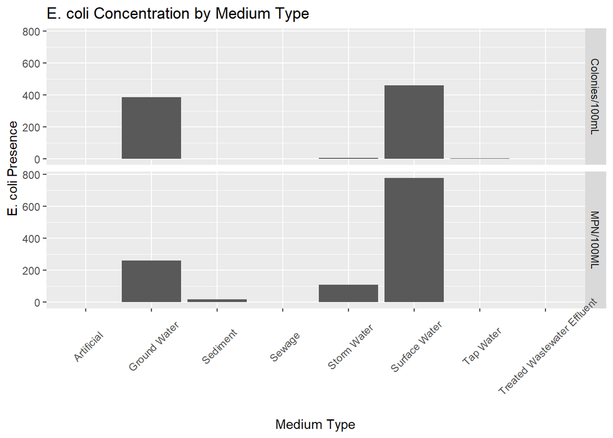

```r
# Visualization 3 - Bar Graph displaying E. coli Presence by Medium type and separated by unit
ggplot(ecoli_data, aes(x = MEDIUM)) + geom_bar(alpha = 1) + theme(axis.text.x = element_text(angle = 45, vjust = 0.7)) + labs(title = 'E. coli Concentration by Medium Type', x = "Medium Type", y = "E. coli Presence") + facet_grid(UNIT ~ .)
```

# Explatory Analysis

### Finding factors found high E. coli

```r
# Watersheds with the highest and lowest average E. coli counts (Colonies/100mL)
mean_water <- Water_Quality %>% filter(UNIT == "Colonies/100mL")
mean_water <- mean_water %>% group_by(WATERSHED) %>% summarise(mean_ecoli = mean(RESULT, na.rm = TRUE)) %>% arrange(desc(mean_ecoli))

top_five <- Water_Quality %>% filter(WATERSHED == "Bear Creek" | WATERSHED == "Country Club West" | WATERSHED == "Slaughter Creek" | WATERSHED == "Tennehill Branch" | WATERSHED == "Buttermilk Branch")
top_five <- top_five %>% group_by(PARAMETER) %>% summarise(mean_top = mean(RESULT, na.rm = TRUE)) %>% arrange(desc(mean_top))

print(top_five)
```

```
## # A tibble: 561 × 2
##    PARAMETER                 mean_top
##    <chr>                        <dbl>
##  1 # OF GRIDS SUBSAMPLED           NA
##  2 1+2-CHLORONAPHTHALENE           NA
##  3 2-CHLOROPHENOL                  NA
##  4 2-METHYLNAPHTHALENE             NA
##  5 2-NAPHTHYLAMINE                 NA
##  6 2_3_4_6-TETRACHLOROPHENOL       NA
##  7 2_4-DIMETHYLPHENOL              NA
##  8 2_4-DINITROTOLUENE              NA
##  9 2_4_5-TRICHLOROPHENOL           NA
## 10 2_6-DINITROTOLUENE              NA
## # ℹ 551 more rows
```

```r
bot_five <- Water_Quality %>% filter(WATERSHED == "North Fork Dry Creek East" | WATERSHED == "Marble Creek" | WATERSHED == "White Branch" | WATERSHED == "Decker Creek" | WATERSHED == "Turkey Creek")
bot_five <- bot_five %>% group_by(PARAMETER) %>% summarise(mean_bot = mean(RESULT, na.rm = TRUE)) %>% arrange(desc(mean_bot))

print(bot_five)
```

```
## # A tibble: 479 × 2
##    PARAMETER                  mean_bot
##    <chr>                         <dbl>
##  1 1_2-DIPHENYLHYDRAZINE            NA
##  2 1_2_4_5-TETRACHLOROBENZENE       NA
##  3 1_3-DICHLOROBENZENE              NA
##  4 1_4-DICHLOROBENZENE              NA
##  5 2-METHYLPHENOL (O-CRESOL)        NA
##  6 2-NAPHTHYLAMINE                  NA
##  7 2-NITROANILINE                   NA
##  8 2-NITROPHENOL                    NA
##  9 2_4-DINITROPHENOL                NA
## 10 2_4-DINITROTOLUENE               NA
## # ℹ 469 more rows
```

```r
# Watersheds with the highest and lowest average E. coli counts (MPN/100mL)
mean_water_v2 <- Water_Quality %>% filter(UNIT == "MPN/100ML")
mean_water_v2 <- mean_water_v2 %>% group_by(WATERSHED) %>% summarise(mean_ecoli_v2 = mean(RESULT, na.rm = TRUE)) %>% arrange(desc(mean_ecoli_v2))

top_five_v2 <- Water_Quality %>% filter(WATERSHED == "Fort Branch" | WATERSHED == "Waller Creek" | WATERSHED == "Lady Bird Lake" | WATERSHED == "Blunn Creek" | WATERSHED == "East Bouldin Creek")
top_five_v2 <- top_five_v2 %>% group_by(PARAMETER) %>% summarise(mean_top_v2 = mean(RESULT, na.rm = TRUE)) %>% arrange(desc(mean_top_v2))

print(top_five_v2)
```

```
## # A tibble: 1,013 × 2
##    PARAMETER               mean_top_v2
##    <chr>                         <dbl>
##  1 # OF BROWN ARUNDO CANES          NA
##  2 # OF GREEN ARUNDO CANES          NA
##  3 # OF GRIDS SUBSAMPLED            NA
##  4 1+2-CHLORONAPHTHALENE            NA
##  5 1_1-DICHLOROETHANE               NA
##  6 1_1-DICHLOROETHYLENE             NA
##  7 1_1_1-TRICHLOROETHANE            NA
##  8 1_1_2-TRICHLOROETHANE            NA
##  9 1_2-DIBROMOETHANE                NA
## 10 1_2-DICHLOROBENZENE              NA
## # ℹ 1,003 more rows
```

```r
bot_five_v2 <- Water_Quality %>% filter(WATERSHED == "Lake Travis" | WATERSHED == "Bohls Hollow" | WATERSHED == "Panther Hollow" | WATERSHED == "South Fork Dry Creek East" | WATERSHED == "Bee Creek West")
bot_five_v2 <- bot_five_v2 %>% group_by(PARAMETER) %>% summarise(mean_bot_v2 = mean(RESULT, na.rm = TRUE)) %>% arrange(desc(mean_bot_v2))

print(bot_five_v2)
```

```
## # A tibble: 346 × 2
##    PARAMETER                     mean_bot_v2
##    <chr>                               <dbl>
##  1 1-NAPHTHYLAMINE                        NA
##  2 2-METHYLNAPHTHALENE                    NA
##  3 2-NITROANILINE                         NA
##  4 2-PICOLINE (2-METHYLPYRIDINE)          NA
##  5 2_3_4_6-TETRACHLOROPHENOL              NA
##  6 2_4-DINITROPHENOL                      NA
##  7 2_4_5-TRICHLOROPHENOL                  NA
##  8 2_6-DICHLOROPHENOL                     NA
##  9 3-METHYLCHOLANTHRENE                   NA
## 10 4-BROMOPHENYL PHENYL ETHER             NA
## # ℹ 336 more rows
```

### Examination One - The relationship between Nutrients and E. coli concentrations

```r
# Filter and adjust data
filtered_nut_data <- Water_Quality %>% filter(PARAMETER == "E COLI BACTERIA" | PARAM_TYPE == "Nutrients") %>% drop_na(RESULT)

# Make sure that all the values in RESULT is numeric
filtered_nut_data$RESULT <- as.numeric(filtered_nut_data$RESULT)

# Separate the E. coli concentration units along with Nutrients
filtered_nut_data1 <- filtered_nut_data %>% filter(UNIT == "Colonies/100mL" | UNIT == "MG/L")
filtered_nut_data2 <- filtered_nut_data %>% filter(UNIT == "MPN/100ML" | UNIT == "MG/L")

# Create vector where data is filtered by the desired parameters
# Group by parameter and watershed summarizing for the average concentration of each, pivoting wider so that each parameter becomes a column
summary_nut_data1 <- filtered_nut_data1 %>% group_by(WATERSHED, PARAMETER) %>% summarise(avg_con = mean(RESULT, na.rm = T)) %>% pivot_wider(names_from = PARAMETER, values_from = avg_con)
summary_nut_data2 <- filtered_nut_data2 %>% group_by(WATERSHED, PARAMETER) %>% summarise(avg_con = mean(RESULT, na.rm = T)) %>% pivot_wider(names_from = PARAMETER, values_from = avg_con)

head(summary_nut_data1)
```

| WATERSHED | AMMONIA AS N | E COLI BACTERIA | NITRATE AS N | NITRATE/NITRITE AS N | NITRITE AS N | NITROGEN AS N | ORTHOPHOSPHORUS AS P | PHOSPHORUS AS P | TOTAL KJELDAHL NITROGEN AS N | AMMONIUM AS NH4-N | NITRATE AS NO3 | NITRITE AS NO2 | PHOSPHATE AS PO4 |
| --- | --- | --- | --- | --- | --- | --- | --- | --- | --- | --- | --- | --- | --- |
| Barton Creek | 0.02605658 | 48.05205 | 0.7885714 | 1.0020731 | 0.002 | 1.41 | 0.13880474 | 0.14037108 | 1.4724630 | NA | NA | NA | NA |
| Bear Creek | 0.03095837 | 787.51852 | 0.7575000 | 0.5307713 | NA | 0.76 | 0.01309975 | 0.09112299 | 1.1111182 | NA | NA | NA | NA |
| Bear Creek West | 0.01500000 | 148.00000 | 0.1170000 | 0.4390000 | NA | NA | 0.02680000 | 0.01350000 | 0.1600000 | NA | NA | NA | NA |
| Bee Creek | 0.02420625 | 44.00000 | 1.0384500 | 0.7445182 | NA | NA | 0.02084211 | 0.01440000 | 0.2952857 | NA | NA | NA | NA |
| Bee Creek West | NA | NA | NA | NA | NA | NA | 0.00400000 | NA | 0.1765000 | NA | NA | NA | NA |
| Big Sandy Creek | 0.00800000 | NA | NA | NA | NA | NA | NA | 0.03720000 | 0.1040000 | NA | NA | NA | NA |

```r
head(summary_nut_data2)
```

| WATERSHED | AMMONIA AS N | E COLI BACTERIA | NITRATE AS N | NITRATE/NITRITE AS N | NITRITE AS N | NITROGEN AS N | ORTHOPHOSPHORUS AS P | PHOSPHORUS AS P | TOTAL KJELDAHL NITROGEN AS N | AMMONIUM AS NH4-N | NITRATE AS NO3 | NITRITE AS NO2 | PHOSPHATE AS PO4 |
| --- | --- | --- | --- | --- | --- | --- | --- | --- | --- | --- | --- | --- | --- |
| Barton Creek | 0.02605658 | 69.39316 | 0.7885714 | 1.0020731 | 0.002 | 1.41 | 0.13880474 | 0.14037108 | 1.4724630 | NA | NA | NA | NA |
| Bear Creek | 0.03095837 | 1999.33226 | 0.7575000 | 0.5307713 | NA | 0.76 | 0.01309975 | 0.09112299 | 1.1111182 | NA | NA | NA | NA |
| Bear Creek West | 0.01500000 | 54.12500 | 0.1170000 | 0.4390000 | NA | NA | 0.02680000 | 0.01350000 | 0.1600000 | NA | NA | NA | NA |
| Bee Creek | 0.02420625 | 53.25000 | 1.0384500 | 0.7445182 | NA | NA | 0.02084211 | 0.01440000 | 0.2952857 | NA | NA | NA | NA |
| Bee Creek West | NA | 21.40000 | NA | NA | NA | NA | 0.00400000 | NA | 0.1765000 | NA | NA | NA | NA |
| Big Sandy Creek | 0.00800000 | 129.60000 | NA | NA | NA | NA | NA | 0.03720000 | 0.1040000 | NA | NA | NA | NA |

### All Ammonia Analysis

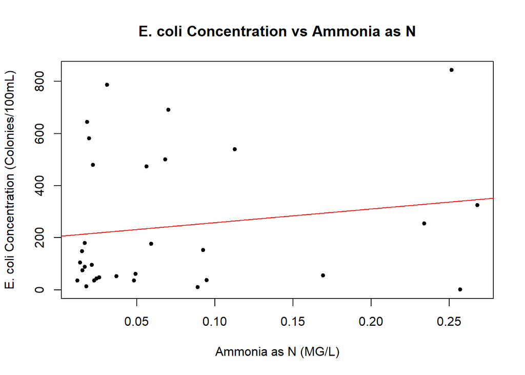

```r
# Making sure all values are finite
summary_amm_data1 <- summary_nut_data1[is.finite(summary_nut_data1$'AMMONIA AS N') & is.finite(summary_nut_data1$'E COLI BACTERIA'),]
summary_amm_data2 <- summary_nut_data2[is.finite(summary_nut_data2$'AMMONIA AS N') & is.finite(summary_nut_data2$'E COLI BACTERIA'),]

# Renaming columns
summary_amm_data1 <- summary_amm_data1 %>% rename(E_COLI_BACTERIA = 'E COLI BACTERIA')
summary_amm_data2 <- summary_amm_data2 %>% rename(E_COLI_BACTERIA = 'E COLI BACTERIA')

summary_amm_data1 <- summary_amm_data1 %>% rename(AMMONIA_AS_N = 'AMMONIA AS N')
summary_amm_data2 <- summary_amm_data2 %>% rename(AMMONIA_AS_N = 'AMMONIA AS N')

# Making sure all the values are numeric
summary_amm_data1$AMMONIA_AS_N <- as.numeric(summary_amm_data1$AMMONIA_AS_N)
summary_amm_data1$E_COLI_BACTERIA <- as.numeric(summary_amm_data1$E_COLI_BACTERIA)

summary_amm_data2$AMMONIA_AS_N <- as.numeric(summary_amm_data2$AMMONIA_AS_N)
summary_amm_data2$E_COLI_BACTERIA <- as.numeric(summary_amm_data2$E_COLI_BACTERIA)

# Create visualization for the concentrations of E. coli to the concentration of Ammonia
plot(summary_amm_data1$AMMONIA_AS_N, summary_amm_data1$E_COLI_BACTERIA, main = 'E. coli Concentration vs Ammonia as N', xlab = 'Ammonia as N (MG/L)', ylab = 'E. coli Concentration (Colonies/100mL)', pch = 20)

# Add a regression line
regression_amm1 <- lm(E_COLI_BACTERIA ~ AMMONIA_AS_N, data = summary_amm_data1)

abline(regression_amm1, col = "red")
```

```r
# The coefficients of the regression line
print(regression_amm1)
```

```
##
## Call:
## lm(formula = E_COLI_BACTERIA ~ AMMONIA_AS_N, data = summary_amm_data1)
##
## Coefficients:
##  (Intercept)  AMMONIA_AS_N
##        206.4         522.0
```

```r
# The regression stats
summary(regression_amm1)
```

```
##
## Call:
## lm(formula = E_COLI_BACTERIA ~ AMMONIA_AS_N, data = summary_amm_data1)
##
## Residuals:
##    Min     1Q Median     3Q    Max
## -339.6 -175.9 -108.5  247.8  565.0
##
## Coefficients:
##              Estimate Std. Error t value Pr(>|t|)
## (Intercept)     206.4       64.3   3.210  0.00324 **
## AMMONIA_AS_N    522.0      604.0   0.864  0.39454
## ---
## Signif. codes:  0 '***' 0.001 '**' 0.01 '*' 0.05 '.' 0.1 ' ' 1
##
## Residual standard error: 261.9 on 29 degrees of freedom
## Multiple R-squared:  0.02511,    Adjusted R-squared:  -0.008507
## F-statistic: 0.7469 on 1 and 29 DF,  p-value: 0.3945
```

```r
# Displays the R-squared value for these two variables
cat("R-squared:", summary(regression_amm1)$r.squared)
```

```
## R-squared: 0.02511008
```

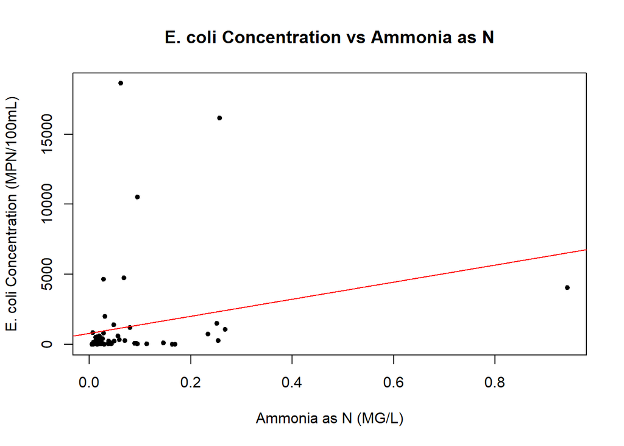

```r
# Create visualization for the concentrations of E. coli to the concentration of Ammonia
plot(summary_amm_data2$AMMONIA_AS_N, summary_amm_data2$E_COLI_BACTERIA, main = 'E. coli Concentration vs Ammonia as N', xlab = 'Ammonia as N (MG/L)', ylab = 'E. coli Concentration (MPN/100mL)', pch = 20)

# Add a regression line
regression_amm2 <- lm(E_COLI_BACTERIA ~ AMMONIA_AS_N, data = summary_amm_data2)

abline(regression_amm2, col = "red")
```

```r
# The coefficients of the regression line
print(regression_amm2)
```

```
##
## Call:
## lm(formula = E_COLI_BACTERIA ~ AMMONIA_AS_N, data = summary_amm_data2)
##
## Coefficients:
##  (Intercept)  AMMONIA_AS_N
##        791.9        6079.9
```

```r
# The regression stats
summary(regression_amm2)
```

```
##
## Call:
## lm(formula = E_COLI_BACTERIA ~ AMMONIA_AS_N, data = summary_amm_data2)
##
## Residuals:
##     Min      1Q  Median      3Q     Max
## -2483.9  -950.9  -817.7  -600.4 17447.0
##
## Coefficients:
##              Estimate Std. Error t value Pr(>|t|)
## (Intercept)     791.9      489.7   1.617   0.1112
## AMMONIA_AS_N   6079.9     3250.0   1.871   0.0663 .
## ---
## Signif. codes:  0 '***' 0.001 '**' 0.01 '*' 0.05 '.' 0.1 ' ' 1
##
## Residual standard error: 3345 on 59 degrees of freedom
## Multiple R-squared:  0.056,  Adjusted R-squared:   0.04
## F-statistic:   3.5 on 1 and 59 DF,  p-value: 0.06634
```

```r
# Displays the R-squared value for these two variables
cat("R-squared:", summary(regression_amm2)$r.squared)
```

```
## R-squared: 0.05599514
```

##### As seen both R-squared values, there seems to be a weak, but positive correlation between ammonia and E. coli concentration.

#### All Nitrate Analysis

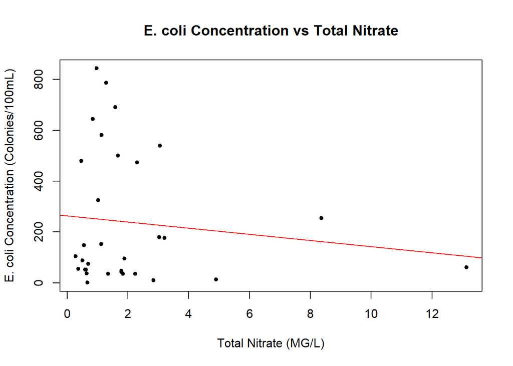

```r
# Combining all the nutrient values that contain N (Nitrogen)
summary_nit_data1 <- summary_nut_data1 %>% mutate(TOTAL_NITRATE = coalesce(`NITRATE AS N`, 0) + coalesce(`NITRATE/NITRITE AS N`, 0) + coalesce(`NITRATE AS NO3`, 0))
summary_nit_data2 <- summary_nut_data2 %>% mutate(TOTAL_NITRATE = coalesce(`NITRATE AS N`, 0) + coalesce(`NITRATE/NITRITE AS N`, 0) + coalesce(`NITRATE AS NO3`, 0))

# Making sure all values are finite
summary_nit_data1 <- summary_nit_data1[is.finite(summary_nit_data1$TOTAL_NITRATE) & is.finite(summary_nit_data1$'E COLI BACTERIA'),]
summary_nit_data2 <- summary_nit_data2[is.finite(summary_nit_data2$TOTAL_NITRATE) & is.finite(summary_nit_data2$'E COLI BACTERIA'),]

# Renaming columns
summary_nit_data1 <- summary_nit_data1 %>% rename(E_COLI_BACTERIA = 'E COLI BACTERIA')
summary_nit_data2 <- summary_nit_data2 %>% rename(E_COLI_BACTERIA = 'E COLI BACTERIA')

# Making sure all the values are numeric
summary_nit_data1$TOTAL_NITRATE <- as.numeric(summary_nit_data1$TOTAL_NITRATE)
summary_nit_data1$E_COLI_BACTERIA <- as.numeric(summary_nit_data1$E_COLI_BACTERIA)

summary_nit_data2$TOTAL_NITRATE <- as.numeric(summary_nit_data2$TOTAL_NITRATE)
summary_nit_data2$E_COLI_BACTERIA <- as.numeric(summary_nit_data2$E_COLI_BACTERIA)

# Create visualization for the concentrations of E. coli to the concentration of Nitrate
plot(summary_nit_data1$TOTAL_NITRATE, summary_nit_data1$E_COLI_BACTERIA, main = 'E. coli Concentration vs Total Nitrate', xlab = 'Total Nitrate (MG/L)', ylab = 'E. coli Concentration (Colonies/100mL)', pch = 20)

# Add a regression line
regression_nit1 <- lm(E_COLI_BACTERIA ~ TOTAL_NITRATE, data = summary_nit_data1)

abline(regression_nit1, col = "red")
```

```r
# The coefficients of the regression line
print(regression_nit1)
```

```
##
## Call:
## lm(formula = E_COLI_BACTERIA ~ TOTAL_NITRATE, data = summary_nit_data1)
##
## Coefficients:
##   (Intercept)  TOTAL_NITRATE
##        263.51         -12.08
```

```r
# The regression stats
summary(regression_nit1)
```

```
##
## Call:
## lm(formula = E_COLI_BACTERIA ~ TOTAL_NITRATE, data = summary_nit_data1)
##
## Residuals:
##    Min     1Q Median     3Q    Max
## -254.4 -201.1 -126.7  226.1  591.5
##
## Coefficients:
##               Estimate Std. Error t value Pr(>|t|)
## (Intercept)     263.51      59.85   4.402 0.000125 ***
## TOTAL_NITRATE   -12.08      18.25  -0.662 0.513204
## ---
## Signif. codes:  0 '***' 0.001 '**' 0.01 '*' 0.05 '.' 0.1 ' ' 1
##
## Residual standard error: 261.2 on 30 degrees of freedom
## Multiple R-squared:  0.01439,    Adjusted R-squared:  -0.01847
## F-statistic: 0.4379 on 1 and 30 DF,  p-value: 0.5132
```

```r
# Displays the R-squared value for these two variables
cat("R-squared:", summary(regression_nit1)$r.squared)
```

```
## R-squared: 0.01438562
```

```r
# Create visualization for the concentrations of E. coli to the concentration of Nitrate
plot(summary_nit_data2$TOTAL_NITRATE, summary_nit_data2$E_COLI_BACTERIA, main = 'E. coli Concentration vs Total Nitrate', xlab = 'Total Nitrate (MG/L)', ylab = 'E. coli Concentration (MPN/100mL)', pch = 20)
print(plot)
```

```
## function (x, y, ...)
## UseMethod("plot")
## <bytecode: 0x0000023283ecd1b0>
## <environment: namespace:base>
```

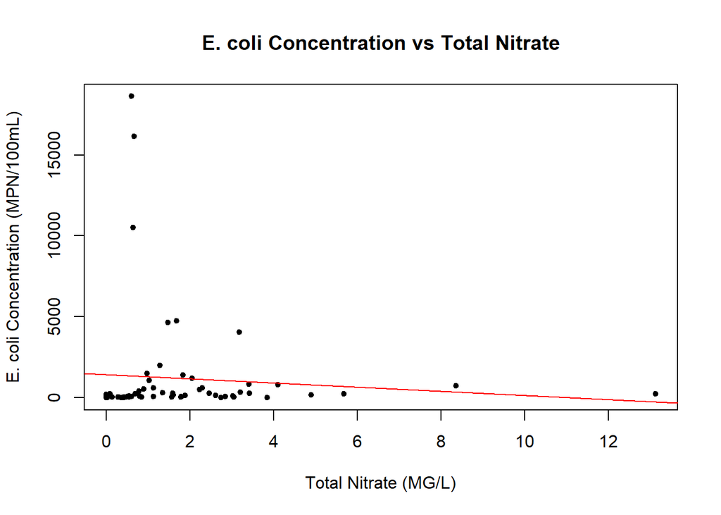

```r
# Add a regression line
regression_nit2 <- lm(E_COLI_BACTERIA ~ TOTAL_NITRATE, data = summary_nit_data2)

abline(regression_nit2, col = "red")
```

```r
# The coefficients of the regression line
print(regression_nit2)
```

```
##
## Call:
## lm(formula = E_COLI_BACTERIA ~ TOTAL_NITRATE, data = summary_nit_data2)
##
## Coefficients:
##   (Intercept)  TOTAL_NITRATE
##        1424.6         -129.1
```

```r
# The regression stats
summary(regression_nit2)
```

```
##
## Call:
## lm(formula = E_COLI_BACTERIA ~ TOTAL_NITRATE, data = summary_nit_data2)
##
## Residuals:
##     Min      1Q  Median      3Q     Max
## -1423.6 -1289.4  -987.6  -497.4 17270.9
##
## Coefficients:
##               Estimate Std. Error t value Pr(>|t|)
## (Intercept)     1424.6      549.5   2.593   0.0119 *
## TOTAL_NITRATE   -129.1      199.8  -0.646   0.5206
## ---
## Signif. codes:  0 '***' 0.001 '**' 0.01 '*' 0.05 '.' 0.1 ' ' 1
##
## Residual standard error: 3381 on 61 degrees of freedom
## Multiple R-squared:  0.006799,   Adjusted R-squared:  -0.009483
## F-statistic: 0.4176 on 1 and 61 DF,  p-value: 0.5206
```

```r
# Displays the R-squared value for these two variables
cat("R-squared:", summary(regression_nit2)$r.squared)
```

```
## R-squared: 0.006799202
```

##### As seen by both R-squared values, there seems to be a very weak and negative correlation between Nitrate and E. coli concentrations.

#### All Phosphorus Analysis

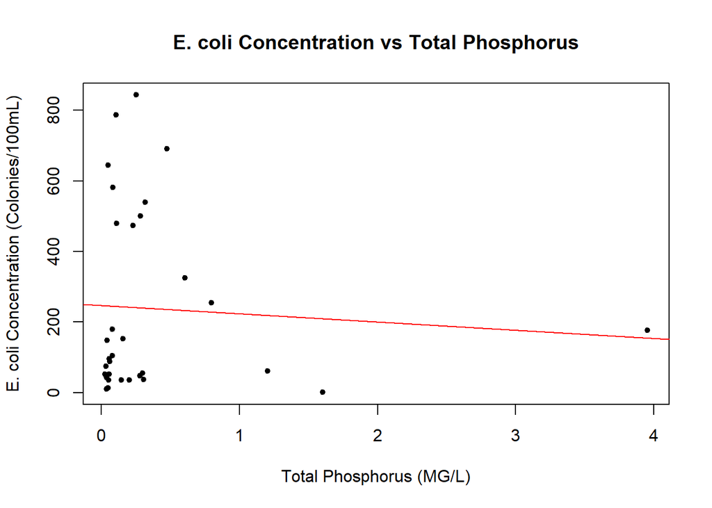

```r
# Combining all the nutrient values that contain P (Phosphorus)
summary_pho_data1 <- summary_nut_data1 %>% mutate(TOTAL_PHOSPHORUS = coalesce(`ORTHOPHOSPHORUS AS P`, 0) + coalesce(`PHOSPHORUS AS P`, 0))
summary_pho_data2 <- summary_nut_data2 %>% mutate(TOTAL_PHOSPHORUS = coalesce(`ORTHOPHOSPHORUS AS P`, 0) + coalesce(`PHOSPHORUS AS P`, 0))

# Making sure all values are finite
summary_pho_data1 <- summary_pho_data1[is.finite(summary_pho_data1$TOTAL_PHOSPHORUS) & is.finite(summary_pho_data1$'E COLI BACTERIA'),]
summary_pho_data2 <- summary_pho_data2[is.finite(summary_pho_data2$TOTAL_PHOSPHORUS) & is.finite(summary_pho_data2$'E COLI BACTERIA'),]

# Renaming columns
summary_pho_data1 <- summary_pho_data1 %>% rename(E_COLI_BACTERIA = 'E COLI BACTERIA')
summary_pho_data2 <- summary_pho_data2 %>% rename(E_COLI_BACTERIA = 'E COLI BACTERIA')

# Making sure all the values are numeric
summary_pho_data1$TOTAL_PHOSPHORUS <- as.numeric(summary_pho_data1$TOTAL_PHOSPHORUS)
summary_pho_data1$E_COLI_BACTERIA <- as.numeric(summary_pho_data1$E_COLI_BACTERIA)

summary_pho_data2$TOTAL_PHOSPHORUS <- as.numeric(summary_pho_data2$TOTAL_PHOSPHORUS)
summary_pho_data2$E_COLI_BACTERIA <- as.numeric(summary_pho_data2$E_COLI_BACTERIA)

# Create visualization for the concentrations of E. coli to the concentration of Phosphorus
plot(summary_pho_data1$TOTAL_PHOSPHORUS, summary_pho_data1$E_COLI_BACTERIA, main = 'E. coli Concentration vs Total Phosphorus', xlab = 'Total Phosphorus (MG/L)', ylab = 'E. coli Concentration (Colonies/100mL)', pch = 20)

# Add a regression line
regression_pho1 <- lm(E_COLI_BACTERIA ~ TOTAL_PHOSPHORUS, data = summary_pho_data1)

abline(regression_pho1, col = "red")
```

```r
# The coefficients of the regression line
print(regression_pho1)
```

```
##
## Call:
## lm(formula = E_COLI_BACTERIA ~ TOTAL_PHOSPHORUS, data = summary_pho_data1)
##
## Coefficients:
##      (Intercept)  TOTAL_PHOSPHORUS
##           247.04            -23.22
```

```r
# The regression stats
summary(regression_pho1)
```

```
##
## Call:
## lm(formula = E_COLI_BACTERIA ~ TOTAL_PHOSPHORUS, data = summary_pho_data1)
##
## Residuals:
##    Min     1Q Median     3Q    Max
## -235.4 -196.4 -145.0  232.8  602.0
##
## Coefficients:
##                  Estimate Std. Error t value Pr(>|t|)
## (Intercept)        247.04      52.21   4.732 4.96e-05 ***
## TOTAL_PHOSPHORUS   -23.22      63.56  -0.365    0.717
## ---
## Signif. codes:  0 '***' 0.001 '**' 0.01 '*' 0.05 '.' 0.1 ' ' 1
##
## Residual standard error: 262.5 on 30 degrees of freedom
## Multiple R-squared:  0.00443,    Adjusted R-squared:  -0.02876
## F-statistic: 0.1335 on 1 and 30 DF,  p-value: 0.7174
```

```r
# Displays the R-squared value for these two variables
cat("R-squared:", summary(regression_pho1)$r.squared)
```

```
## R-squared: 0.004430102
```

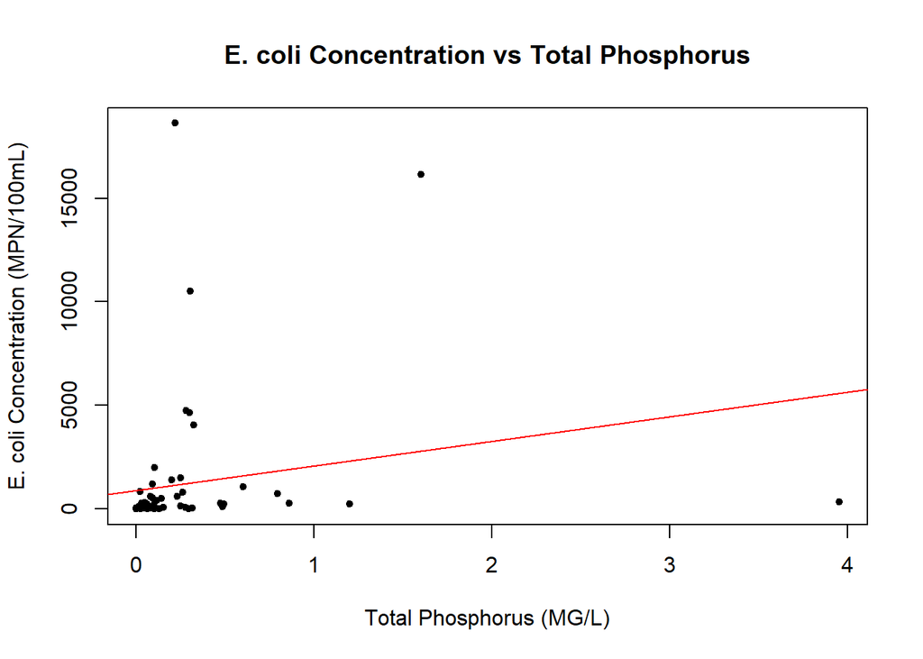

```r
# Create visualization for the concentrations of E. coli to the concentration of Phosphorus
plot(summary_pho_data2$TOTAL_PHOSPHORUS, summary_pho_data2$E_COLI_BACTERIA, main = 'E. coli Concentration vs Total Phosphorus', xlab = 'Total Phosphorus (MG/L)', ylab = 'E. coli Concentration (MPN/100mL)', pch = 20)

# Add a regression line
regression_pho2 <- lm(E_COLI_BACTERIA ~ TOTAL_PHOSPHORUS, data = summary_pho_data2)

abline(regression_pho2, col = "red")
```

```r
# The coefficients of the regression line
print(regression_pho2)
```

```
##
## Call:
## lm(formula = E_COLI_BACTERIA ~ TOTAL_PHOSPHORUS, data = summary_pho_data2)
##
## Coefficients:
##      (Intercept)  TOTAL_PHOSPHORUS
##            887.9            1186.0
```

```r
# The regression stats
summary(regression_pho2)
```

```
##
## Call:
## lm(formula = E_COLI_BACTERIA ~ TOTAL_PHOSPHORUS, data = summary_pho_data2)
##
## Residuals:
##     Min      1Q  Median      3Q     Max
## -5250.4  -961.0  -862.2  -563.9 17466.1
##
## Coefficients:
##                  Estimate Std. Error t value Pr(>|t|)
## (Intercept)         887.9      465.1   1.909    0.061 .
## TOTAL_PHOSPHORUS   1186.0      764.7   1.551    0.126
## ---
## Signif. codes:  0 '***' 0.001 '**' 0.01 '*' 0.05 '.' 0.1 ' ' 1
##
## Residual standard error: 3327 on 61 degrees of freedom
## Multiple R-squared:  0.03794,    Adjusted R-squared:  0.02217
## F-statistic: 2.405 on 1 and 61 DF,  p-value: 0.1261
```

```r
# Displays the R-squared value for these two variables
cat("R-squared:", summary(regression_pho2)$r.squared)
```

```
## R-squared: 0.03793738
```

##### As seen by the two R-squared values, there seems to be no correlation between phosphorus and E. coli concentration.

### Examination Two - The relationship between Enterococcus and E. coli

```r
# Filter and adjust data
filtered_ent_data <- Water_Quality %>% filter(PARAMETER == "E COLI BACTERIA" | PARAMETER == "ENTEROCOCCUS") %>% drop_na(RESULT)

# Make sure that all the values in RESULT are numeric
filtered_ent_data$RESULT <- as.numeric(filtered_ent_data$RESULT)

# Separate the E. coli concentration units along with Enterococcus concentration
filtered_ent_data1 <- filtered_ent_data %>% filter(UNIT == "Colonies/100mL" | PARAMETER == "ENTEROCOCCUS")
filtered_ent_data2 <- filtered_ent_data %>% filter(UNIT == "MPN/100ML" | PARAMETER == "ENTEROCOCCUS")

# Create vector where data is filtered by the desired parameters
# Group by parameter and watershed summarizing for the average concentration of each, pivoting wider so that each parameter becomes a column
summary_ent_data1 <- filtered_ent_data1 %>% group_by(WATERSHED, PARAMETER) %>% summarise(avg_con = mean(RESULT, na.rm = T)) %>% pivot_wider(names_from = PARAMETER, values_from = avg_con)
summary_ent_data2 <- filtered_ent_data2 %>% group_by(WATERSHED, PARAMETER) %>% summarise(avg_con = mean(RESULT, na.rm = T)) %>% pivot_wider(names_from = PARAMETER, values_from = avg_con)

# Making sure all values are finite
summary_ent_data1 <- summary_ent_data1[is.finite(summary_ent_data1$'ENTEROCOCCUS') & is.finite(summary_ent_data1$'E COLI BACTERIA'),]
summary_ent_data2 <- summary_ent_data2[is.finite(summary_ent_data2$'ENTEROCOCCUS') & is.finite(summary_ent_data2$'E COLI BACTERIA'),]

# Renaming columns
summary_ent_data1 <- summary_ent_data1 %>% rename(E_COLI_BACTERIA = 'E COLI BACTERIA')
summary_ent_data2 <- summary_ent_data2 %>% rename(E_COLI_BACTERIA = 'E COLI BACTERIA')

head(summary_ent_data1)
```

| WATERSHED | E_COLI_BACTERIA | ENTEROCOCCUS |
| --- | --- | --- |
| Bear Creek | 787.5185 | 2269.50 |
| Waller Creek | 500.0000 | 57565.71 |

```r
head(summary_ent_data2)
```

| WATERSHED | E_COLI_BACTERIA | ENTEROCOCCUS |
| --- | --- | --- |
| Bear Creek | 1999.332 | 2269.50 |
| Blunn Creek | 4659.150 | 34500.00 |
| Fort Branch | 18616.808 | 31354.00 |
| Waller Creek | 4750.508 | 57565.71 |

#### Enterococcus Analysis

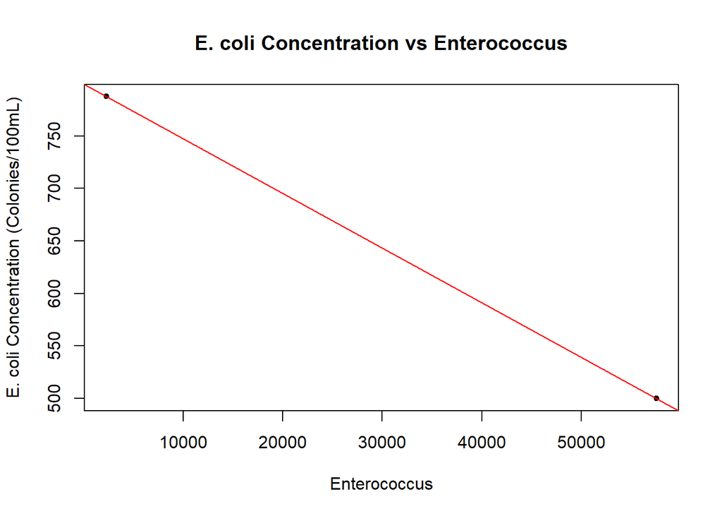

```r
# Some cleaning
summary_ent_data1 <- na.omit(summary_ent_data1)
summary_ent_data2 <- na.omit(summary_ent_data2)

# Making sure all numbers are numeric
summary_ent_data1$ENTEROCOCCUS <- as.numeric(summary_ent_data1$ENTEROCOCCUS)
summary_ent_data1$E_COLI_BACTERIA <- as.numeric(summary_ent_data1$E_COLI_BACTERIA)

summary_ent_data2$ENTEROCOCCUS <- as.numeric(summary_ent_data2$ENTEROCOCCUS)
summary_ent_data2$E_COLI_BACTERIA <- as.numeric(summary_ent_data2$E_COLI_BACTERIA)

# Create visualization for the concentrations of E. coli to the concentration of Enterococcus
plot(summary_ent_data1$ENTEROCOCCUS, summary_ent_data1$E_COLI_BACTERIA, main = 'E. coli Concentration vs Enterococcus', xlab = 'Enterococcus', ylab = 'E. coli Concentration (Colonies/100mL)', pch = 20)

# Add a regression line
regression_enter1 <- lm(E_COLI_BACTERIA ~ ENTEROCOCCUS, data = summary_ent_data1)

abline(regression_enter1, col = "red")
```

```r
# The coefficients of the regression line
print(regression_enter1)
```

```
##
## Call:
## lm(formula = E_COLI_BACTERIA ~ ENTEROCOCCUS, data = summary_ent_data1)
##
## Coefficients:
##  (Intercept)  ENTEROCOCCUS
##     799.3190       -0.0052
```

```r
# The regression stats
summary(regression_enter1)
```

```
##
## Call:
## lm(formula = E_COLI_BACTERIA ~ ENTEROCOCCUS, data = summary_ent_data1)
##
## Residuals:
## ALL 2 residuals are 0: no residual degrees of freedom!
##
## Coefficients:
##              Estimate Std. Error t value Pr(>|t|)
## (Intercept)  799.3190        NaN     NaN      NaN
## ENTEROCOCCUS  -0.0052        NaN     NaN      NaN
##
## Residual standard error: NaN on 0 degrees of freedom
## Multiple R-squared:      1,  Adjusted R-squared:    NaN
## F-statistic:   NaN on 1 and 0 DF,  p-value: NA
```

```r
# Displays the R-squared value for these two variables
cat("R-squared:", summary(regression_enter1)$r.squared)
```

```
## R-squared: 1
```

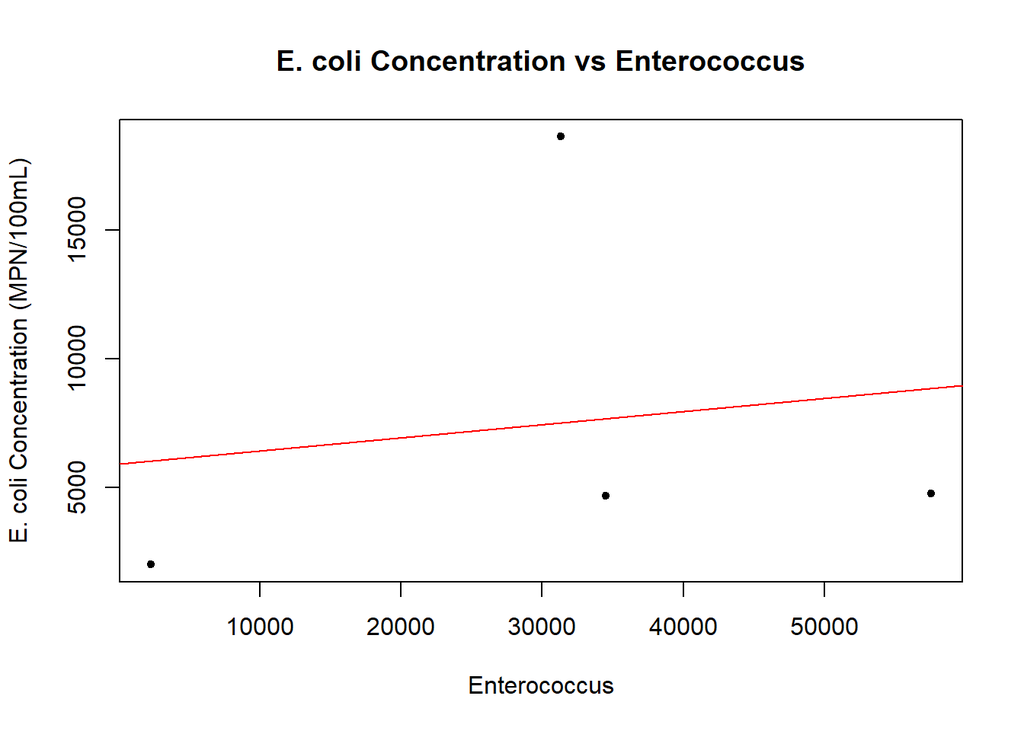

```r
# Create visualization for the concentrations of E. coli to the concentration of Enterococcus
plot(summary_ent_data2$ENTEROCOCCUS, summary_ent_data2$E_COLI_BACTERIA, main = 'E. coli Concentration vs Enterococcus', xlab = 'Enterococcus', ylab = 'E. coli Concentration (MPN/100mL)', pch = 20)

# Add a regression line
regression_enter2 <- lm(E_COLI_BACTERIA ~ ENTEROCOCCUS, data = summary_ent_data2)

abline(regression_enter2, col = "red")
```

```r
# The coefficients of the regression line
print(regression_enter2)
```

```
##
## Call:
## lm(formula = E_COLI_BACTERIA ~ ENTEROCOCCUS, data = summary_ent_data2)
##
## Coefficients:
##  (Intercept)  ENTEROCOCCUS
##    5.898e+03     5.119e-02
```

```r
# The regression stats
summary(regression_enter2)
```

```
##
## Call:
## lm(formula = E_COLI_BACTERIA ~ ENTEROCOCCUS, data = summary_ent_data2)
##
## Residuals:
##     1     2     3     4
## -4015 -3005 11114 -4094
##
## Coefficients:
##               Estimate Std. Error t value Pr(>|t|)
## (Intercept)  5.898e+03  8.580e+03   0.687    0.563
## ENTEROCOCCUS 5.119e-02  2.315e-01   0.221    0.846
##
## Residual standard error: 9095 on 2 degrees of freedom
## Multiple R-squared:  0.02385,    Adjusted R-squared:  -0.4642
## F-statistic: 0.04888 on 1 and 2 DF,  p-value: 0.8455
```

```r
# Displays the R-squared value for these two variables
cat("R-squared:", summary(regression_enter2)$r.squared)
```

```
## R-squared: 0.02385485
```

### Examination Three - The relationship between Fecal Coliform bacteria and E. coli

```r
# Filter and adjust data
filtered_fecal_data <- Water_Quality %>% filter(PARAMETER == "E COLI BACTERIA" | PARAMETER == "FECAL COLIFORM BACTERIA") %>% drop_na(RESULT)

# Make sure that all the values in RESULT are numeric
filtered_fecal_data$RESULT <- as.numeric(filtered_fecal_data$RESULT)

# Separate the E. coli concentration units along with Fecal Coliform Bacteria concentration
filtered_fecal_data1 <- filtered_fecal_data %>% filter(UNIT == "Colonies/100mL" | PARAMETER == "FECAL COLIFORM BACTERIA")
filtered_fecal_data2 <- filtered_fecal_data %>% filter(UNIT == "MPN/100ML" | PARAMETER == "FECAL COLIFORM BACTERIA")

# Create vector where data is filtered by the desired parameters
# Group by parameter and watershed summarizing for the average concentration of each, pivoting wider so that each parameter becomes a column
summary_fecal_data1 <- filtered_fecal_data1 %>% group_by(WATERSHED, PARAMETER) %>% summarise(avg_con = mean(RESULT, na.rm = T)) %>% pivot_wider(names_from = PARAMETER, values_from = avg_con)
summary_fecal_data2 <- filtered_fecal_data2 %>% group_by(WATERSHED, PARAMETER) %>% summarise(avg_con = mean(RESULT, na.rm = T)) %>% pivot_wider(names_from = PARAMETER, values_from = avg_con)
# Making sure all values are finite
summary_fecal_data1 <- summary_fecal_data1[is.finite(summary_fecal_data1$'FECAL COLIFORM BACTERIA') & is.finite(summary_fecal_data1$'E COLI BACTERIA'),]
summary_fecal_data2 <- summary_fecal_data2[is.finite(summary_fecal_data2$'FECAL COLIFORM BACTERIA') & is.finite(summary_fecal_data2$'E COLI BACTERIA'),]

summary_fecal_data1 <- summary_fecal_data1 %>% rename(E_COLI_BACTERIA = 'E COLI BACTERIA')
summary_fecal_data2 <- summary_fecal_data2 %>% rename(E_COLI_BACTERIA = 'E COLI BACTERIA')

# Renaming columns
summary_fecal_data1 <- summary_fecal_data1 %>% rename(FECAL_COLIFORM_BACTERIA = 'FECAL COLIFORM BACTERIA')
summary_fecal_data2 <- summary_fecal_data2 %>% rename(FECAL_COLIFORM_BACTERIA = 'FECAL COLIFORM BACTERIA')

head(summary_fecal_data1)
```

| WATERSHED | E_COLI_BACTERIA | FECAL_COLIFORM_BACTERIA |
| --- | --- | --- |
| Barton Creek | 48.05205 | 62.86928 |
| Bear Creek | 787.51852 | 154.00000 |
| Bee Creek | 44.00000 | 85.00000 |
| Boggy Creek | 36.00000 | 1125.85714 |
| Brushy Creek | 10.75000 | 70.00000 |
| Bull Creek | 473.55972 | 2852.36923 |

```r
head(summary_fecal_data2)
```

| WATERSHED | E_COLI_BACTERIA | FECAL_COLIFORM_BACTERIA |
| --- | --- | --- |
| Barton Creek | 69.39316 | 62.86928 |
| Bear Creek | 1999.33226 | 154.00000 |
| Bee Creek | 53.25000 | 85.00000 |
| Blunn Creek | 4659.15000 | 8808.50000 |
| Boggy Creek | 1404.63462 | 1125.85714 |
| Brushy Creek | 70.00000 | 70.00000 |

#### Fecal Coliform Bacteria Analysis

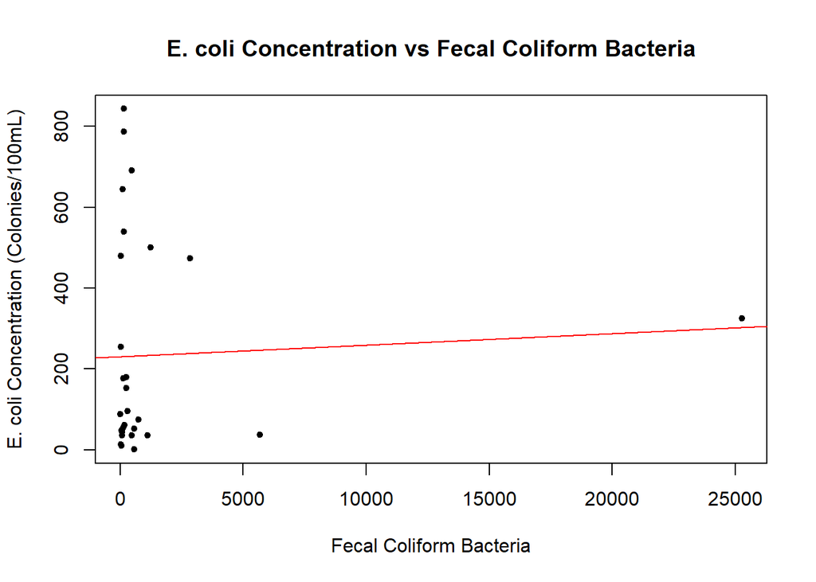

```r
# Some cleaning
summary_fecal_data1 <- na.omit(summary_fecal_data1)
summary_fecal_data2 <- na.omit(summary_fecal_data2)

# Making sure all numbers are numeric
summary_fecal_data1$FECAL_COLIFORM_BACTERIA <- as.numeric(summary_fecal_data1$FECAL_COLIFORM_BACTERIA)
summary_fecal_data1$E_COLI_BACTERIA <- as.numeric(summary_fecal_data1$E_COLI_BACTERIA)

summary_fecal_data2$FECAL_COLIFORM_BACTERIA <- as.numeric(summary_fecal_data2$FECAL_COLIFORM_BACTERIA)
summary_fecal_data2$E_COLI_BACTERIA <- as.numeric(summary_fecal_data2$E_COLI_BACTERIA)

# Create visualization for the concentrations of E. coli to the concentration of Fecal Coliform Bacteria
plot(summary_fecal_data1$FECAL_COLIFORM_BACTERIA, summary_fecal_data1$E_COLI_BACTERIA, main = 'E. coli Concentration vs Fecal Coliform Bacteria', xlab = 'Fecal Coliform Bacteria', ylab = 'E. coli Concentration (Colonies/100mL)', pch = 20)

# Add a regression line
regression_fecal1 <- lm(E_COLI_BACTERIA ~ FECAL_COLIFORM_BACTERIA, data = summary_fecal_data1)

abline(regression_fecal1, col = "red")
```

```r
# The coefficients of the regression line
print(regression_fecal1)
```

```
##
## Call:
## lm(formula = E_COLI_BACTERIA ~ FECAL_COLIFORM_BACTERIA, data = summary_fecal_data1)
##
## Coefficients:
##             (Intercept)  FECAL_COLIFORM_BACTERIA
##               2.301e+02                2.852e-03
```

```r
# The regression stats
summary(regression_fecal1)
```

```
##
## Call:
## lm(formula = E_COLI_BACTERIA ~ FECAL_COLIFORM_BACTERIA, data = summary_fecal_data1)
##
## Residuals:
##    Min     1Q Median     3Q    Max
## -230.8 -186.4 -142.1  235.3  612.7
##
## Coefficients:
##                          Estimate Std. Error t value Pr(>|t|)
## (Intercept)             2.301e+02  5.191e+01   4.433 0.000139 ***
## FECAL_COLIFORM_BACTERIA 2.852e-03  1.069e-02   0.267 0.791597
## ---
## Signif. codes:  0 '***' 0.001 '**' 0.01 '*' 0.05 '.' 0.1 ' ' 1
##
## Residual standard error: 267.2 on 27 degrees of freedom
## Multiple R-squared:  0.002631,   Adjusted R-squared:  -0.03431
## F-statistic: 0.07122 on 1 and 27 DF,  p-value: 0.7916
```

```r
# Displays the R-squared value for these two variables
cat("R-squared:", summary(regression_fecal1)$r.squared)
```

```
## R-squared: 0.002630823
```

```r
# Create visualization for the concentrations of E. coli to the concentration of Fecal Coliform Bacteria
plot(summary_fecal_data2$FECAL_COLIFORM_BACTERIA, summary_fecal_data2$E_COLI_BACTERIA, main = 'E. coli Concentration vs Fecal Coliform Bacteria', xlab = 'Fecal Coliform Bacteria', ylab = 'E. coli Concentration (MPN/100mL)', pch = 20)
print(plot)
```

```
## function (x, y, ...)
## UseMethod("plot")
## <bytecode: 0x0000023283ecd1b0>
## <environment: namespace:base>
```

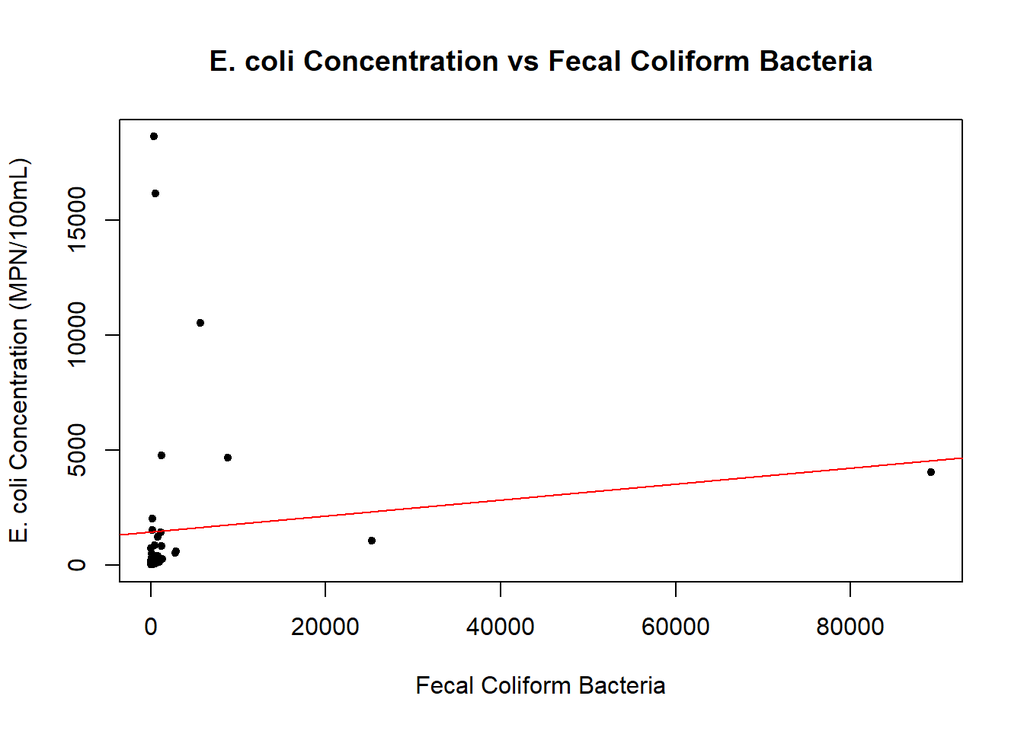

```r
# Add a regression line
regression_fecal2 <- lm(E_COLI_BACTERIA ~ FECAL_COLIFORM_BACTERIA, data = summary_fecal_data2)

abline(regression_fecal2, col = "red")
```

```r
# The coefficients of the regression line
print(regression_fecal2)
```

```
##
## Call:
## lm(formula = E_COLI_BACTERIA ~ FECAL_COLIFORM_BACTERIA, data = summary_fecal_data2)
##
## Coefficients:
##             (Intercept)  FECAL_COLIFORM_BACTERIA
##               1.427e+03                3.493e-02
```

```r
# The regression stats
summary(regression_fecal2)
```

```
##
## Call:
## lm(formula = E_COLI_BACTERIA ~ FECAL_COLIFORM_BACTERIA, data = summary_fecal_data2)
##
## Residuals:
##     Min      1Q  Median      3Q     Max
## -1416.0 -1369.1 -1239.3  -687.9 17176.4
##
## Coefficients:
##                          Estimate Std. Error t value Pr(>|t|)
## (Intercept)             1.427e+03  5.659e+02   2.521   0.0152 *
## FECAL_COLIFORM_BACTERIA 3.493e-02  4.195e-02   0.833   0.4093
## ---
## Signif. codes:  0 '***' 0.001 '**' 0.01 '*' 0.05 '.' 0.1 ' ' 1
##
## Residual standard error: 3813 on 46 degrees of freedom
## Multiple R-squared:  0.01485,    Adjusted R-squared:  -0.006567
## F-statistic: 0.6934 on 1 and 46 DF,  p-value: 0.4093
```

```r
# Displays the R-squared value for these two variables
cat("R-squared:", summary(regression_fecal2)$r.squared)
```

```
## R-squared: 0.0148493
```